# Perception Data Analysis

M2 Stat optional class Analyse de données de Perception

2025-12-19

# 1 Seance 1

### 1.0.1 Introduction

Nous partons d’un **ensemble de stimuli** (par exemple, des assertions, des produits, des échantillons ou des images) qui ont été **conçus selon certains facteurs de variabilité** — c’est ce que l’on appelle la **planification expérimentale**.  
Chaque dimension de ces stimuli peut correspondre à différents **niveaux de difficulté ou d’intensité** (par exemple : *facile*, *moyen*, *difficile*).

Pour ce cours, notre étude ne portera pas sur la perception d’un produit, mais sur celle des “Atomic Habits” (un concept popularisé par James Clear dans son livre éponyme) : de petites habitudes visant un impact environnemental significatif. Les méthodes pourront tout de même être appliquées à un produit et sa perception par des consommmateurs.

Nous avons d’abord établi une liste de 14 assertions. Chaque assertion est une phrase qui explicite une habitude spécifique ainsi que les contraintes ou contreparties associées à son adoption.

Exemple d’assertion : Je consomme uniquement des produits alimentaires de saison, ce qui peut impliquer de renoncer, à la maison comme au restaurant, aux fruits, légumes ou poissons hors saison (par exemple, les agrumes en été ou les tomates en hiver), etc.

### 1.0.2 Definition de la mesure

Une fois les assertions définies, la question centrale était de déterminer la méthode de mesure : Quelle question poser aux consommateurs ? De plus, nous devions décider si les assertions devaient être considérées individuellement ou comme un ensemble.

Nous avons choisi d’analyser les assertions comme un ensemble. Ce choix s’est avéré pertinent car pour obtenir un classement (ranking), les consommateurs devaient évaluer tous les stimuli simultanément.

La question finale posée aux consommateurs est donc la suivante :

**“Classer les habitudes suivantes en fonction de celles que vous pensez être capables de tenir sur le long terme pour significativement réduire votre impact sur l’environnement.”**

### 1.0.3 Classement des stimuli

Les **consommateurs** (ou juges) vont ensuite **classer** ces stimuli en fonction de leurs préférences, en ayant tous les stimuli à disposition.  
On obtient alors une **table de données** dont la structure est la suivante :

- **Lignes** : les individus (ou consommateurs)
- **Colonnes** : les stimuli
- **Valeurs** : les **notes de classement (ranking)**

Ces notes représentent une **mesure de préférence relative** : plus la note est faible, plus l’assertion (le produit) est proche de l’**idéal** du consommateur.

### 1.0.4 Représentation dans l’espace des produits

L’avantage avec cette notion de classement c’est que l’on tend vers un idéal. On veut représenter le consommateur dans l’espace produit à travers son idéal.

L’objectif est de représenter simultanément :

- les **consommateurs** (via leurs idéaux) et
- les **stimuli** (les assertions/les produits)

dans un **même espace perceptif**.

En effet, les données de ranking sont lignes-dépendantes et l’ordre entre les stimuli n’est défini qu’à l’intérieur d’une ligne. Un individu va donc correspondre à un ordonnancement des assertions, et donc plus fondamentalement, les individus sont représentés à travers leurs idéaux, un idéal représentant une vision de la réalité.

L’intérêt de projeter dans le même espace est d’avoir la distance perceptuelle entre un idéal consommateur et un ensemble de stimuli.

Une **analyse en correspondances (AC)** peut être utilisée pour projeter ces informations. Chaque **stimulus** y apparaît comme un **point** et les **consommateurs** sont positionnés autour selon la proximité de leurs préférences.

> **Rappel :**  
> L’AC vise à représenter les **relations entre lignes et colonnes** d’un tableau de contingence.  
> Ici, on cherche à faire **correspondre des idéaux de consommateurs et des assertions (produits)**, c’est-à-dire à mesurer **la distance entre la perception et les stimuli**.

Ainsi, on peut visualiser **quelles assertions (ou produit) sont perçues comme proches des idéaux** des consommateurs.  
Le **plan factoriel** qui en résulte permet d’identifier des **clusters** ou **concepts perceptifs** (groupes de produits ou de préférences similaires).

Si un ideal est proche d’une assertion alors cette assertion est importante pour l’idéal.

On peut donc comparer les objets virtuels (initialement les individus en ligne) par rapport à toutes les colonnes : proximité ou éloignement entre un idéal et les stimuli et une colonne par rapport à toutes les lignes : proximité ou éloignement entre un stimulus et l’ensemble des idéaux.

On peut identifier des clusters d’idéaux qui se rapprochent, et faire émerger les concepts latents derrière les variables qui permettent de savoir ce qui séparent les différents idéaux.

### 1.0.5 Problème d’optimisation

L’analyse repose sur un **problème d’optimisation** : on cherche la représentation qui **reproduit au mieux les distances observées** entre les consommateurs et les stimuli.

$$\sum_i \sum_j (\delta_{ij} - \Delta_{ij})^2$$

- L’indice **i** correspond aux **idéaux** des consommateurs.
- L’indice **j** correspond aux **stimuli** évalués (assertions/produits).
- Le $δ_{ij}$ correspond à la distance entre un idéal **i** et un stimuli **j** sur le plan de représentation
- Le $\Delta_{ij}$ correspond à la distance entre un individu **i** et un stimuli **j** dans le tableau (par exemple le rang choisi par ce consommateur pour ce stimuli)

L’objectif de l’unfolding est de **trouver la configuration de points** (idéaux et stimulis) qui reproduit le mieux les dissimilarités observées entre les idéaux i et les stimuli j.  
Pour y parvenir, on utilise une **descente de gradient**, c’est-à-dire une méthode itérative qui ajuste progressivement les positions des points pour **réduire l’écart entre δ et Δ**.

Le **nombre de dimensions** retenu dépend du problème étudié : on peut dériver par rapport aux **coordonnées des lignes et des colonnes**, selon le nombre d’axes que l’on souhaite représenter.

Chaque **objet** (stimulus ou individu) est donc associé à un **ensemble de coordonnées** dans cet espace multidimensionnel.

### 1.0.6 Qu’est-ce que la MDS (Multidimensional Scaling) ?

La **MDS** (ou **cartographie multidimensionnelle**) est une méthode qui permet de **représenter des objets à partir d’une matrice de distances**.  
Elle cherche une configuration spatiale où les distances entre les points reproduisent le plus fidèlement possible les distances observées entre les objets.

L’**unfolding** (ou **préférence unfolding**) est un **cas particulier de MDS**, dans lequel les données sont **incomplètes ou asymétriques** — typiquement lorsque tous les consommateurs n’évaluent pas tous les produits.

Le résultat est une **carte perceptive** qui représente l’ensemble des **distances entre consommateurs et stimuli**, permettant une visualisation claire des **proximités et différences perçues**.

# 2 Seance 2 (cours 2 et 3)

```r
knitr::opts_knit$set(root.dir = rprojroot::find_rstudio_root_file())
```

## 2.1 Unfolding

### 2.1.1 Rappel sur les données d’unfolding

Le point de départ c’est un jeu de données avec en ligne les individus, en colonne les stimuli et au croisement des lignes et des colonnes le classement / le rang attribué par l’individus au stimuli.

Dans ce jeu de données, chaque ligne est une distance à un idéal.

L’objectif de l’unfolding c’est de représenter dans un même espace les idéaux des individus et les assertions. Sur cet espace on a donc les coordonnées des idéaux.

Le but de l’unfolding va être de minimiser la différence entre nos distance observées (les lignes de notre tableau de données ) et nos distances estimées (les coordonnées des points sur notre graphique). Pour faire cela on va avoir besoin d’une descente de gradient. Cet algorithme dérive les coordonnées x et y jusqu’à converger de façon à ce que le stress soit le plus petit possible.

La question se pose de comment on passe de rang à distance. Il existe pleins de métriques différentes, mais on peut très simplement dire que le premier a une distance de 1, que le deuxième a une distance de 2 et ainsi de suite.

### 2.1.2 Notre jeu de données

Le jeux de données que nous avons ne correspond pas à des données d’unfolding, la structure n’est pas la bonne.  
En colonne nous avons les stimuli, en ligne l’individu et au croisement le rang.  
Pour pouvoir utiliser le package smacof et réaliser l’unfolding, il nous faut en colonne les rangs et au croisement entre individus et rangs, l’assertion.

Pour faire cela, il faut trier pour chaque ligne les assertions par ordre alphabétique et récupérer les rangs correspondants.

Le package *smacof* permet de réaliser l’unfolding. Il faut utiliser la fonction unfolding.

La limite de ce package est qu’il ne prend pas en compte les variables supplémentaires. Il faut donc ruser pour améliorer notre graphique et y rajouter les variables supplémentaires.

Pour ce faire on fait un tableau de données intermédiaire ou on fait correspondre les coordonnées de chaque individu et les valeurs prises par les variables supplémentaires. Ensuite on calcule par modalité de chacune des variables supplémentaires le barycentre.

```r
library(tidyverse)
library(here)

dta <- read.csv(
  here("Markdown/dataset", "Atomic Habits.csv"),
  stringsAsFactors = TRUE,
  sep = ",",
  header = TRUE
)
dta <- drop_na(dta)
names(dta)[6:19] <- as.character(1:14)

final <- read.table(here("Markdown/dataset", "habits_large.csv"), header = TRUE, sep = ",")

library(smacof)
unfolded <- unfolding(final[,2:15])

sup <- dta[,c(1,20:21)]
names(sup) <- c("ID.reponse", "Responsabilite", "Sentiment")
```

```r
supw <- cbind(sup,unfolded$conf.row[2:47,])
supw[,1]<-as.factor(supw[,1])
supw[,2]<-as.factor(supw[,2])
supw[,3]<-as.factor(supw[,3])
summary(supw)
```

```
##    ID.reponse Responsabilite                                        Sentiment
##  8      : 1   1: 1                                                       : 0
##  17     : 1   2: 4           Autres                                      : 4
##  18     : 1   3:12           De l'espoir ("les solutions existent").     :12
##  21     : 1   4:21           De l'indifférence ("ça ne me concerne pas").: 1
##  22     : 1   5: 8           De l'urgence à agir.                        :25
##  23     : 1                  De la résignation ("c'est trop tard").      : 4
##  (Other):40
##        D1                 D2
##  Min.   :-0.54549   Min.   :-0.64549
##  1st Qu.:-0.38066   1st Qu.:-0.34916
##  Median :-0.16391   Median :-0.19020
##  Mean   :-0.05622   Mean   :-0.19246
##  3rd Qu.: 0.21254   3rd Qu.:-0.09793
##  Max.   : 0.62020   Max.   : 0.32086
##
```

```r
points_moyens_responsabilite <- aggregate(
  x = supw[, c("D1", "D2")], # Les variables sur lesquelles calculer la moyenne
  by = list(Responsabilite = supw$Responsabilite), # La variable de regroupement
  FUN = mean # La fonction à appliquer (la moyenne)
)

points_moyens_sentiment <- aggregate(
  x = supw[, c("D1", "D2")], # Les variables sur lesquelles calculer la moyenne
  by = list(Sentiment = supw$Sentiment), # La variable de regroupement
  FUN = mean # La fonction à appliquer (la moyenne)
)
```

```r
# Ajouter de la data illustrative
illus <- dta[,c(1,20:21)]
names(illus)[2:3] <- c("Responsabilite_env", "Sentiment_env")

illus[,1:3] <- lapply(illus, as.factor)

levels(illus$Responsabilite_env) <- c("pas_du_tout_responsable", "peu_responsable", "moy_responsable", "responsable", "tres_responsable")

# nrow(illus)
# nrow(group1)
```

```r
assertions_long <- names(final)[-1]

assertions_courtes <- c(
  "circuits_courts",
  "mobilite_douce",
  "zero_dechet",
  "sans_ia",
  "sans_avion",
  "produits_saison",
  "outils_manuel",
  "chauffage_bas",
  "covoiturage_train",
  "antideforestation",
  "location_pret",
  "vegetalien",
  "seconde_main",
  "veille_off"
)
# nom résumé des assertions

# on renomme les colonnes du df final
colnames(final) <- c("id", assertions_courtes)
```

Création du graph => construit à partir des profils idéaux

```r
library(plotly)

conf_assertions <- as.data.frame(unfolded$conf.col)
rownames(conf_assertions) <- assertions_courtes
conf_ind <- as.data.frame(unfolded$conf.row)

fig <- plot_ly() %>%

  # Individus
  add_trace(data = conf_ind,
            x = ~D1, y = ~D2,
            type = 'scatter', mode = 'markers',
            marker = list(color = 'black', size = 5),
            name = 'Individus') %>%

  # Assertions
  add_trace(data = conf_assertions,
            x = ~D1, y = ~D2,
            type = 'scatter', mode = 'markers+text',
            marker = list(color = 'cadetblue', size = 5),
            text = ~rownames(conf_assertions),
            textfont = list(color = 'cadetblue'),
            textposition = 'top center',
            hovertext = ~assertions_long,  # texte au survol
            hoverinfo = 'text',
            name = 'Assertions') %>%

  # Responsabilité environnementale
  add_trace(data = points_moyens_responsabilite,
            x = ~D1, y = ~D2,
            type = 'scatter', mode = 'markers+text',
            marker = list(color = 'red', size = 5),
            text = ~levels(illus$Responsabilite_env),
            textfont = list(color = 'red'),
            textposition = 'top center',
            name = 'Responsabilité') %>%

  # Sentiment environnemental
  add_trace(data = points_moyens_sentiment,
            x = ~D1, y = ~D2,
            type = 'scatter', mode = 'markers+text',
            marker = list(color = 'green', size = 5),
            text = ~levels(illus$Sentiment_env)[-1],
            textfont = list(color = 'green'),
            textposition = 'top center',
            name = 'Sentiment') %>%


  plotly::layout(title = list(text = "Unfolding Configuration", x = 0.5),
         xaxis = list(title = ""),
         yaxis = list(title = ""),
         plot_bgcolor = 'rgb(242, 242, 242)',
         showlegend = TRUE)

fig
```

[interactive chart not shown]

### 2.1.3 Description de notre graphique

Ce graphique issu de l’unfolding est construit à partir des individus représentés par leurs idéaux. Les idéaux sont de ce point de vue des stimulis virtuels. Les atomic habits sont des stimulis réels. On veut minimiser la différence entre distances observées (entre un individu et un idéal = entre un idéal et un stimuli) et estimées (entre les stimulis entre eux). On souhaite que les individus ayant des idéaux similaires soient représentés proches les uns des autres, et que chaque individu, représenté par son idéal, se trouve à proximité des stimuli qui lui sont proches, c’est-à-dire ceux qui ont été classés parmi ses premiers choix.

A partir des données obtenues, on peut dire qu’il semble y avoir plusieurs clusters d’atomic habits :

- végétalien, antidéforestation, zéro déchet, circuits courts, seconde main (haut à gauche)
- produits saison, chauffage bas (centre)
- outil manuels, covoiturage, veille appareils, mobilité douce (bas à gauche)
- sans avion, ia

Le premier cluster semble regrouper des atomic habits correspondant à des habitudes que des individus se sentant impliqués et responsables dans la réduction de leur empreinte environnementale estiment pouvoir maintenir sur le long terme. Ces habitudes reflètent des actions choisies et assumées, liées à des modes de vie et de consommation engagés, telles que devenir végétarien, adopter le zéro déchet ou n’acheter que des produits de seconde main, et font partie de l’identité de ces individus. Par ailleurs, les modalités «très responsables» et «moyennement responsables» se situent également de ce côté du graphique. Ce groupe représente ainsi des idéaux de personnes engagées, conscientes de leur responsabilité, et prêtes à opérer des changements importants dans leur mode de vie pour réduire leur impact environnemental

Le cluster 2 regroupe des atomic habits liées au chauffage (abaisser la température à son domicile) et à la consommation de produits de saison. Ils reflètent des individus se sentant peu concernés par les questions environnementales.

Le cluster 4 regroupe des habitudes telles que limiter les voyages en avion ou ne pas utiliser d’IA. Il reflète des individus se sentant “pas du tout responsables” de leur impact environnemental. Ces individus peuvent être qualifiés de détachés, ou résignés, car ils ne sentent pas concernés, et le changement davantage vécu comme une contrainte qu’un choix.

## 2.2 Profil Idéal

Un profil sensoriel c’est un ensemble de caractéristiques évaluées par nos sens. Un profil idéal est un profil particulier: un ensemble de caractéristiques qui maximisent le liking (appréciation hédonique) d’un produit (ou autre objet étudié).

Pour créer un profil idéal, on réunit un panel de consommateurs qui vont évaluer des produits sur des descripteurs. En plus de ces descripteurs il leur est demandé de donner une note d’appréciation hédonique et de remplir un profil idéal pour le produit. Ce profil idéal correspond au niveau idéal d’un descripteur pour un consommateur. Un consommateur peut avoir un, ou plusieurs idéaux.

Pour comprendre la perception sensorielle d’un produit par le consommateur, le consommateur va noter le produit sur différents attributs (ex : sucrosité, fondant, croquant…), ce qui va permettre d’établir le profil sensoriel de ces produits. Ces mesures sont normalement réalisées par des panels entrainés de juges auxquels on ne demande pas la préférence (jugement hédonique). Ici, on chercehe à comprendre le lien pouvant exister entre profil sensoriel et liking, donc avec des données appariés : les jugements hédoniques de mêmes produits sont effectués par les mêmes juges les ayant testés et décrits ces produits selon les attributs sensoriels.

Afin de tendre vers un produit idéal, on demande au consommateur, pour chaque produit, le niveau idéal de l’attribut j pour ce produit. Cela permet d’établir les profils idéaux des produits pour chacun des consommateurs: qui sont donc les idéaux. Logiquement, le produit idéal correspondant par définition au produit donc l’ensemble des caractéristiques maximisent l’appréciation par le consommateur, alors le liking du produit idéal (avec les caractéristiques données par le consommateur) dépassent le liking du produit testé (sinon, cela ne sert à rien). Or, on ne connait pas ce liking. De plus, seules l’appréciation et les données de profil sensoriel (évoquées plus haut) sont évaluées sur des produits physiques. Pour le profil idéal, les données sont évaluées sur des produits fictifs, introduisant une grande incertitude individuelle et de confiance en ces données, ce qui sera évoqué plus bas.

Si on a 5 produits, 12 descripteurs, 10 juges, le tableau est de la forme suivante :

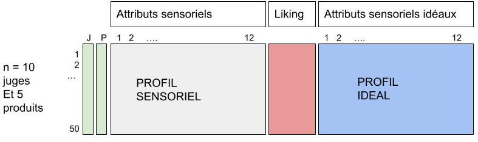

Si on a 60 juges et qu’on transforme les données individuelles de perception sensorielle en profils sensoriels, alors, la forme du tableau de données est la suivante :

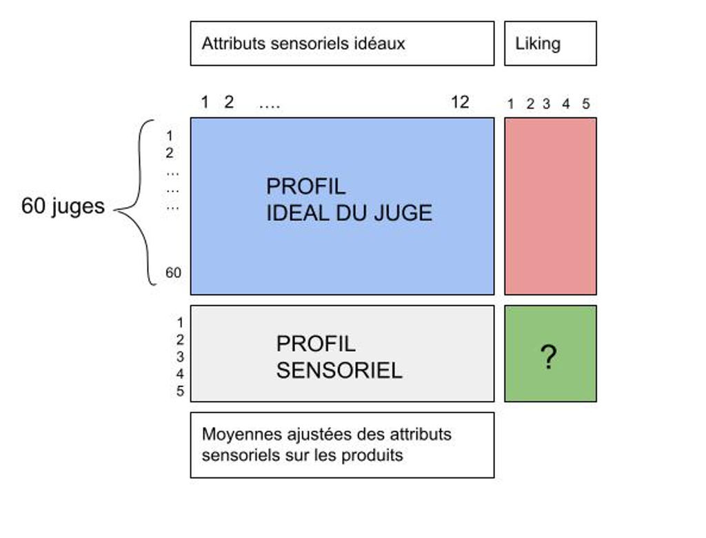

On peut construire à partir de ce tableau bleu une ACP sur les profils idéaux permettant d’obtenir un espace factoriel de représentation des idéaux. Les individus sont représentés par leurs idéaux, et on projette dans cet espace de profil idéal les produits réels. Si deux points sont proches, les deux consommateurs ont des idéaux proches.

Les produits réels sont des individus illustratifs que l’on projette comme s’ils étaient des idéaux. Si un individu est proche d’un point représentant un produit réel, alors, l’individu a pour idéal un produit proche du produit réel.

Les variables sont les descripteurs sensoriels et on projette en variable illustratives les notes hédoniques de chaque produit dans le cercle des corrélations. La variable se projette dans la direction sensorielle d’un idéal. Par exemple, la variable “salé” projetée d’un côté du cercle des corrélation, indiquera que les produits se situant dans la même direction sur le graphique des individus prennent des notes idéales fortes pour le sel. Les individus concernés apprécient les produits salés.

La première étape dans ce cas est de regarder la consistence de notre jeu de données.

Le bloc de données le plus fragile est le bloc du profil idéal car c’est très très subjectif. En effet, le consommateur a évalué d’une part : - les profils sensoriels des produits : attributs sensoriels sur des produits physiques - son appréciation hédonique de chacun de ces produits : réponse spontanée à un instant T sur un produit présenté - évaluation des profils idéaux : le niveau que devrait prendre l’attribut sensoriel pour atteindre le niveau idéal pour ce consommateur, donc ces mesures sont réalisées à partir de produits imaginaires et sont très subjectives.

De plus, on ne connait pas l’appréciation hédonique perçue par le consommateur d’un produit qui correspondrait à ce profil idéal.

Il faut que l’appréciation du produit idéal dépasse l’appréciation des produits évalués car les produits idéaux maximisent le liking.

### 2.2.1 Première vérification consistence hédonique

Un idéal sous entend que l’on préfère l’idéal au produit présenté. On peut verifier cela en faisant pour chaque individu un modèle de prédiction de liking, l’utiliser pour estimer la note attribuée à ses profils idéaux et regarder si ces notes sont meilleures que celles de la réalité.

### 2.2.2 Deuxième verification consistence sensorielle

L’avantage dans la méthode du profil idéal c’est qu’à l’inverse du préférence mapping, les profils sensoriels et les données hédonique sont appareillées. On aimerait que la note des descripteurs de l’idéal et de l’observé aillent dans le même sens par rapport à l’hédonique. (si un produit est très apprécié lorsqu’il est sucré, que l’idéal le soit aussi)

### 2.2.3 Troisième verification corrélation

On peut également regarder les coefficients de corrélation. Tout d’abord, on calcule la corrélation entre les profils sensoriels des produits (tableau de moyennes ajustées) et les notes hédoniques attribués par chaque consommateur. Cela mesure si, pour un consommateur donné, les produits qu’il apprécie le plus sont bien ceux qui possèdent les caractéristiques sensorielles qu’il préfère. Par exemple, un juge a goûté 5 produits, chacun ayant un profil sensoriel, on peut identifier quels types de produits il aime ou n’aime pas. On s’attend alors à ce que les coefficients entre les vrais produits et les notes hédoniques soient très élevés : cela indiquerait une relation cohérente entre les perceptions sensorielles et les préférences exprimées.

Ensuite, on calcule une corrélation entre le premier coefficient et les attributs idéaux du consommateur. On cherche alors à savoir si cette logique de préférence est cohérente avec les idéaux déclarés du consommateur. On compare les corrélations observées entre produits et notes (r(y,h)) avec ces profils idéaux (z). Cela permet de mesurer si les tendances observées dans les notations hédoniques sont en accord avec ce que le consommateur dit aimer. Si le coefficient global est élevé, cela veut dire que le consommateur note de manière cohérente : ses préférences hédoniques sont alignées avec ses goûts idéaux.

## 2.3 Profil idéal exemple des politiques publiques

### 2.3.1 Adaptation de la méthode à ce nouvel exemple

On essaie d’adopter la méthodologie de profil idéal à un tout autre sujet, les politiques publiques. Il faut transformer les différents éléments et les adapter à ce sujet :

- Que seront les produits pour des PP? les produits seront des propositions de loi. On veut un espace des produits le plus varié possible (logique du plan expérimental) donc on établit des facteurs expérimentaux représentant un espace de produit le plus varié possible. Ces facteurs expérimentaux sont : le facteur économique (modèle économique), le facteur de budget (financement) et le facteur sociétal (valeurs). Chacun de ces facteurs prend 2 modalités.

Pour le facteur économique: libéral ou communiste Pour le facteur financier: rigoriste (priorité à l’équilibre) ou priorité à l’investissement Pour le facteur de valeurs: socio-économique traditionnel ou plus moderne (fortes contraintes écologiques)

- Que seront les attributs sensoriels pour des PP? les attributs sensoriels sont des mesures sur les propositions de loi. Voici quelques exemples de mesures: à quel point cette mesure appose une forte pression fiscale sur les entreprises (échelle quanti de 1 à 10 par exemple), à quel point cette mesure priorise le soutien social, à quel point cette mesure priorise la compétitivité des entreprises, la réduction de la dette publique, etc….
- Que sera le jugement hédonique pour des PP? Dans cet exemple, le jugement hédonique d’une proposition de loi est la propotion de la volonté d’un élu à voter en faveur de l’adoption de cette politique publique, par exemple sur une échelle numérique, de 1 à 10 (1 = pas du tout prêt à voter en faveur, 10 = totalement prêt à voter en faveur de cette mesure)
- Quels seront les profils idéaux pour les PP? les profils idéaux sont les apports à faire aux propositions de loi (d’un point de vue de la mesure) pour qu’il maximisent l’appréciation hédonique. On veut voir comment il faut que les propositions de loi soient améliorées pour augmenter la propension à voter en faveur la proposition de loi.

### 2.3.2 Définition des produits

Plan expérimental :

prop n° F1 F2 F3 1 -1 -1 -1 Libéral – Rigoriste – Traditionnel 2 -1 -1 +1 Libéral – Rigoriste – Écologique 3 -1 +1 -1 Libéral – Investissement – Traditionnel 4 -1 +1 +1 Libéral – Investissement – Écologique 5 +1 -1 -1 Communiste - Rigoriste – Traditionnel 6 +1 -1 +1 Communiste - Rigoriste – Écologique 7 +1 +1 -1 Communiste – Investissement – Traditionnel 8 +1 +1 +1 Communiste – Investissement – Écologique

Exemples de propositions de loi correspondant à ce plan expérimental : 1- Programme de compétitivité et discipline budgétaire, avec réduction progressive des cotisations sociales patronales, stabilisation du niveau de dépenses publiques et simplification des normes pour l’emploi et l’investissement, pour réduire le déficit public et soutenir l’activité par l’offre

2- Programme de transition verte par le marché et budget strict : Évolution progressive des normes environnementales, mise en place de crédits d’impôts pour innovations bas-carbone accompagnées d’incitations et de redéploiements budgétaires existants

3- Grand plan d’investissement dans l’innovation et les infrastructures; Dépenses publiques accrues dans les infrastructures numériques et transport, allègement fiscal ciblé sur les entreprises qui embauchent ou exportent, recours partiel à la dette pour financer la croissance future; pour favoriser croissance, emploi, compétitivité.

4- Marché et innovations pour la transition écologique : R&D subventionnée pour l’énergie verte et l’économie circulaire, suppression progressive des subventions aux énergies fossiles, facilité donnée aux entreprises innovantes via des incitations fiscales

5- Programme de rigueur social et souveraineté nationale : maintient strict de l’équilibre budgétaire, recentrage de la dépense publique sur les services essentiels (santé, éducation, sécurité), nationalisation partielle des secteurs stratégiques, encadrement des salaires élevés pour renforcer la justice sociale dans un cadre budgétaire maîtrisé

6- État planificateur de la transition écologique : régulation forte des secteurs polluants (quotas, interdictions progressives), redirection du budget existant vers rénovation énergétique et transports doux, aides sociales conditionnées à participation à projets écologiques locaux

7- Grand plan d’investissement public national : relance de l’industrie et de l’emploi par la commande publique, protection des secteurs stratégiques et réindustrialisation du territoire, financement par emprunt national et création d’un fonds souverain, dans une logique d’indépendance économique et de solidarité sociale

8- Plan massif pour les services publiques et la transition écologique, hausse des impôts sur les sociétés et écotaxe, et recours à la dette

# 3 Seance 3 (cours 4 et 5)

```r
knitr::opts_knit$set(root.dir = rprojroot::find_rstudio_root_file())
```

## 3.1 Tâches de tri

Les **tâches de tri** consistent à donner à des juges un **ensemble d’objets ou d’assertions** et à leur demander de les **regrouper** en catégories. Les données obtenues sont qualitative.

- On ne donne **pas de prisme au juge** (ni critères, ni liste de groupes prédéfinis)
- On cherche à **comprendre la grille de lecture de la personne**, c’est-à-dire la façon dont elle perçoit les similitudes et différences entre les stimuli.
- On peut ensuite demander au juge de **caractériser** chaque groupe (nommer le groupe)

Ce type de tâche s’intéresse directement au processus cognitif mis en jeu pour organiser l’information.

**exemple : 12 stimuli et 55 individus** Supposons que l’on dispose de 12 stimuli et de 55 individus. Quelle forme peut prendre le tableau de données ?

- Tableau 55 x 12 : chaque individu est décrit par sa manière de trier ou de catégoriser les 12 stimuli.
- Tableau 12 x 55 : Chaque colonne représente alors un système de tri proposé par un individu (un « set de stimuli » organisé par cette personne). Ce tableau permet de **calculer des distances entre stimuli**, en fonction de la fréquence avec laquelle ils sont mis ensemble par les différents juges. À l’intersection, on peut rattacher les **labels ou commentaires** associés aux groupes par les juges : ces commentaires fournissent des critères d’interprétation des dimensions qui ressortiront des analyses (par exemple, « sucré », « chimique », « métallique », etc.).

A partir de ces tableaux plusieurs types d’analyses sont envisageables. Sur un tableau 12 × 55, on peut réaliser une **Analyse des Correspondances Multiples (ACM)**. L’objectif est d’explorer la structure des relations entre stimuli et individus, et de représenter l’espace perceptif.

En agrégeant les informations de tri, on peut construire un tableau 12 × 12 de co-occurrences. Chaque case indique le nombre de fois où deux objets ont été mis ensemble par les juges.On peut alors effectuer une Analyse des Correspondances (AC) sur ce tableau. Ce type d’analyse se rattache au principe de l’unfolding, où l’on cherche à représenter la proximité entre objets en fonction des co-choix des individus. Cependant, il existe des limites à ce tableau puisqu’on perd l’information des commentaires, il faut alors les ajouter comme éléments supplémentaires. On perd de la variabilité individuelle, car on a agrégé l’ensemble des tris, les différences entre juges ne sont plus visibles.

## 3.2 Tri séquentiel aglomératif

### 3.2.1 Saturation

Pour des concepts, trier 12, 25 ou 40 concepts reste relativement gérable pour le juge. En revanche, pour les odeurs, trier 12, 25 ou 40 stimulis olfactifs entraîne **rapidement une saturation** (factigue sensorielle et difficulté à maintenir une comparaison fine entre tous les stimulis).

C’est ici qu’intervient la planification expérimentale : il devient nécessaire d’utiliser des plans incomplets, car on ne peut pas demander au juge de comparer toutes les odeurs en une seule fois.

Cependant, l’utilisation de ces plans fait perdre de l’information. Les distances entre stimuli ne sont plus exactement les mêmes que si tous les stimuli avaient été vus ensemble. Cela peut modifier la structure perceptive que l’on observe (on parle de problème de focale, l’espace perceptif dépend du sous-ensemble présenté).

**Les stimuli forment un tout**. La perception d’un stimulus dépend aussi du contexte, c’est-à-dire des autres stimuli présentés avec lui. En fragmentant ce tout, on risque d’altérer la représentation globale.

Il faut donc pallier ce problème de distance. Si l’on décide de **faire plusieurs sessions**, il devient nécessaire de réduire le nombre de comparaisons à effectuer à chaque session, tout en gardant une structure cohérente.

### 3.2.2 Principe du tri séquentiel aglomératif

#### 3.2.2.1 Etape 1 : passer des individus aux groupes.

Lors d’une première session, chaque juge doit trier un nombre limité d’odeurs (par exemple 10 odeurs). Ils forment des groupes à partir de ce sous-ensemble. Cette étape permet de passer des réponses individuelles à des groupes structurants (des pôles perceptifs).

#### 3.2.2.2 Etape 2 : associer les nouveaux stimuli aux groupes.

Dans les sessions suivantes, les nouveaux stimuli sont associés aux groupes existants, qui jouent le rôle de pôles ou points d’ancrage.

Les juges peuvent :

- attribuer un nouveau stimulus à un groupe existant,
- modifier un groupe si besoin,
- ou créer un nouveau groupe si le stimulus ne correspond à aucun pôle existant.

L’intérêt est qu’on réduit le nombre de distances à estimer. On ne compare plus chaque stimulus avec tous les autres, mais on l’associe à un groupe. On **freine l’espace de perception**. L’espace perceptif est structuré autour de quelques pôles stables, les nouveaux stimuli viennent s’ancrer dans cet espace au lieu de redéfinir entièrement la carte perceptive à chaque fois.

## 3.3 Tri divisif

Dans cette tâche de tri, on va s’intéresser au sujets, qui vont trier nos objets, mais on va surtout s’intéresser au processus cognitif de ces sujets.

### 3.3.1 Principe du tri

Cette fois ci, notre exemple sera le tri de différentes carte par des enfants. Les enfants auront devant eux 16 cartes représentant un graphisme simple, comprenant 7 informations à 2 modalités : - La couleur du fond de carte (rouge / jaune) - Le style du fond de carte (uni / dégradé) - La forme affichée (carré / triangle) - La position de la forme (haut / bas) - La couleur de la forme (bleu / vert) - La taille de la forme (grand petit) - Le type de contour de la forme (trait plein / trait pointillé)

On demande aux enfants de créer deux groupes distinct à partir du premier groupe (toutes les cartes). Puis autant de fois qu’ils le veulent, ils peuvent diviser à nouveau ces différents groupes en différents groupes. On obtient alors une suite de partitions emboitées, une hiérarchie entre ces partitions. C’est un processus de tri divisif. Grâce à cela, on peut extraire la première feature, le critère de division le plus fréquent chez les sujets. En observant ensuite les chemins de pensées, on peut s’intéresser aux réflexions atypiques, pour mieux comprendre les processus cognitif chez ces enfants.

### 3.3.2 Principe d’analyse des chemins de pensées

Pour pouvoir représenter les choses, on voudrait avoir un plan factoriel qui sépare les 16 cartes d’abord en fonction du critère de séparation le plus utilisé (1er axe du plan factoriel), puis en fonction du second (2e axe du plan factoriel). Intéressons nous ici à un enfant. En ACM, une des représentations des variables est le carré des liaisons, où chaque variable est représentée en fonction l’importance de sa liaison avec le premier axe et le second axe du plan factoriel. On aimerait donc avoir en variable les différentes étapes du tri pour cet enfant. On pourrait alors observer quel étape est corrélée avec le premier axe, puis quelle seconde division est corrélée au premier et second axe… On aurait alors une représentation du chemin de pensée de cet enfant. Mais puisque l’on a plusieurs enfants différents, une ACM de suffit pas. On accorderait autant d’importance à chaque enfant, et l’on veut traiter ces variables comme appartenant à différents groupes (un par enfant). On peut donc se dire que l’ACM est en réalité une AFM dont chaque groupe est constitué d’une seule variable, puis on induit une hiérarchie grâce à une AFMH en ajoutant un groupe par enfant.

### 3.3.3 Analyse des différentes tâches de tri

On va commencer par analyser les tâches de tri en elles-mêmes. Pour avoir une idée de l’évolution du chemin de pensée selon différentes information. Le tableau contient donc en ligne tous les enfants, et en colonne des informations sur eux ou sur le déroulement de la tâche de tri.

```r
library(readxl)
library(FactoMineR)
library(here)
donnees <- read_xls(here("Markdown/dataset","Descriptive.xls"))
summary(donnees)
```

```
##       Ind             Jour                        Prénom
##  Min.   : 80.0   Min.   :2020-01-08 00:00:00   Length:170
##  1st Qu.:125.2   1st Qu.:2020-01-11 00:00:00   Class :character
##  Median :169.5   Median :2020-01-12 00:00:00   Mode  :character
##  Mean   :168.6   Mean   :2020-01-12 06:46:35
##  3rd Qu.:211.8   3rd Qu.:2020-01-12 00:00:00
##  Max.   :255.0   Max.   :2020-01-18 00:00:00
##  Nbdehiérarchies Nbdeclassesfinal Nbdecritèrescités Nbdecritèresutilisés
##  Min.   :1.000   Min.   :2.000    Min.   :0.000     Min.   :1.000
##  1st Qu.:2.000   1st Qu.:6.000    1st Qu.:2.000     1st Qu.:3.000
##  Median :3.000   Median :8.000    Median :3.000     Median :3.000
##  Mean   :2.524   Mean   :6.829    Mean   :2.629     Mean   :3.029
##  3rd Qu.:3.000   3rd Qu.:8.000    3rd Qu.:3.000     3rd Qu.:4.000
##  Max.   :4.000   Max.   :8.000    Max.   :5.000     Max.   :5.000
##   Symétrique        Tempspasséaveclenfant  classetemps         Age
##  Length:170         Min.   :120.0         Min.   :1.000   Min.   : 3.000
##  Class :character   1st Qu.:210.0         1st Qu.:2.000   1st Qu.: 5.000
##  Mode  :character   Median :265.0         Median :2.000   Median : 7.000
##                     Mean   :292.5         Mean   :2.429   Mean   : 6.588
##                     3rd Qu.:348.8         3rd Qu.:3.000   3rd Qu.: 8.750
##                     Max.   :770.0         Max.   :5.000   Max.   :10.000
##      Sexe             Lunettes             Juge           DroitierGaucher
##  Length:170         Length:170         Length:170         Length:170
##  Class :character   Class :character   Class :character   Class :character
##  Mode  :character   Mode  :character   Mode  :character   Mode  :character
##
##
##
##   Introverti        Aretournélescartes    Ecole           Couleurchvx
##  Length:170         Length:170         Length:170         Length:170
##  Class :character   Class :character   Class :character   Class :character
##  Mode  :character   Mode  :character   Mode  :character   Mode  :character
##
##
##
```

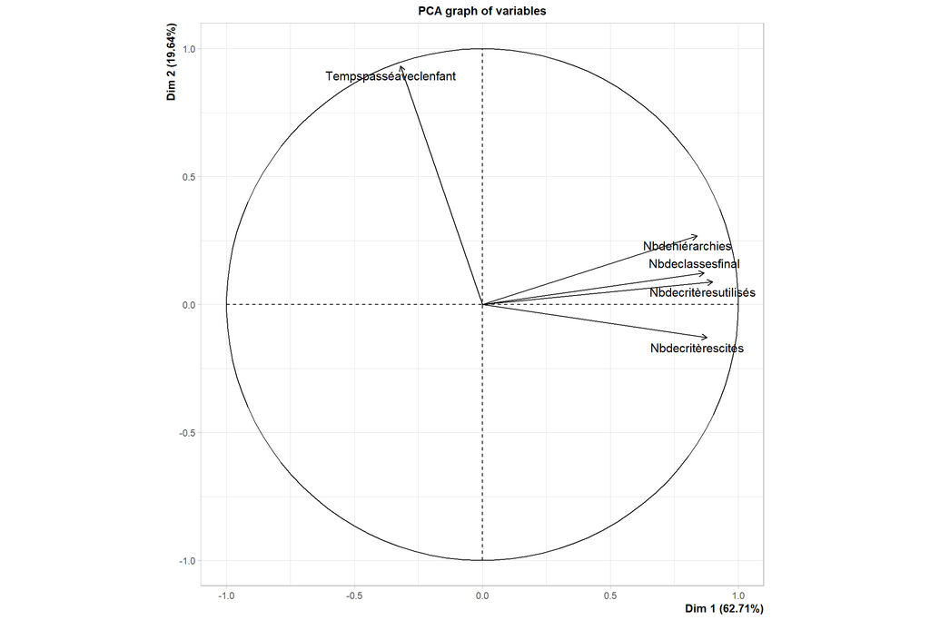

```r
donnees_1 <- donnees[,c(4,5,6,7,9,11)]

res.PCA<- PCA(donnees_1, quali.sup=c(6), graph = F)
plot.PCA(res.PCA, choix = "var")
```

On voit sur le graphe des variables que les des variables que le plan factoriel est très corrélé aux variables suivantes : Nombre de critère cité, utilisés, nombre de hiérarchie et nombre de classes finales sont très liées à la première dimension. Le temps passé avec l’enfant est lui très lié à la seconde dimension. On suppose que le processus de réflexion de l’enfant est très lié à la complexité du tri final, et au temps passé à sur cette tâche.

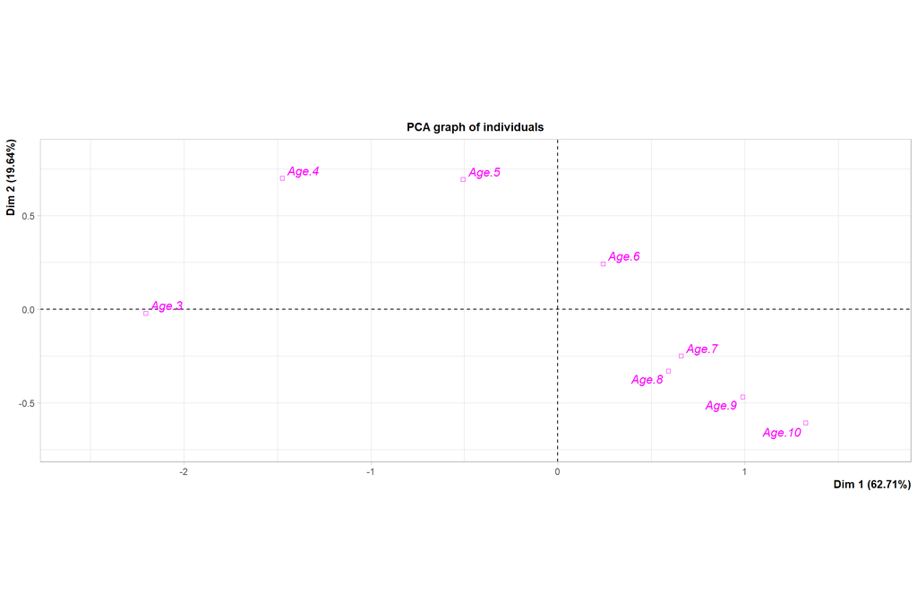

```r
plot.PCA(res.PCA, invisible="ind")
```

On remarque ici très nettement une évolution de la réflexion en fonction de l’âge de l’enfant. Il est donc très intéressant de voir les chemins de pensée associés à cette représentation

### 3.3.4 Analyse des processus cognitif

On récupère donc le tableau de données comportant les partitions

```r
library(tidyverse)
### On veut réaliser le graphique avec les chemins de pensées.

Tri <- read.table(here("Markdown/dataset","trih.txt"), header = TRUE, stringsAsFactors = TRUE)

Tri <- Tri %>% mutate(across(everything(), as.factor))
print(Tri[,1:9])
```

```
##    Stimuli E80.H1 E80.H2 E82.H1 E82.H2 E82.H3 E83.H1 E83.H2 E83.H3
## 1        A      2      8      1      1      8      1      1      1
## 2        B      2      1      2      2      1      2      3      5
## 3        C      1      2      1      4      2      1      2      2
## 4        D      2      7      2      3      7      2      3      3
## 5        E      2      6      1      4      6      1      2      2
## 6        F      1      3      1      1      3      1      1      1
## 7        G      2      6      1      4      6      1      2      2
## 8        H      1      5      2      2      5      2      4      4
## 9        I      2      7      2      3      7      2      3      3
## 10       J      1      5      2      2      5      2      4      4
## 11       K      2      8      1      1      8      1      1      1
## 12       L      1      4      2      3      4      2      4      4
## 13       M      1      4      2      3      4      2      4      4
## 14       N      2      1      2      2      1      2      3      5
## 15       O      1      2      1      4      2      1      2      2
## 16       P      1      3      1      1      3      1      1      1
```

Pour réaliser l’AFMH, on doit définir la hiérarchie au travers des variable. Ici, dès qu’il y a un “H1” dans le nom d’une des variables, cela signifie qu’on passe à un nouvel enfant (avec sa première hiérarchie). On crée donc un vecteur de taille “nombre d’enfant” avec pour chaque valeur, le nombre de partitions réalisées par un enfant.

```r
# Tri <- Tri[,c(1:50)]

# Exemple de vecteur
x <- names(Tri[-1])

# Étape 1 : compter le nombre de "H1"
n <- sum(grepl("H1", x))
cat("Nombre de 'H1' :", n, "\n")
```

```
## Nombre de 'H1' : 170
```

```r
# Étape 2 : trouver les positions de chaque "H1"
pos <- which(grepl("H1", x))

# Étape 3 : calculer le nombre d’éléments avant le prochain "H1"
# Pour chaque "H1", on regarde la distance jusqu’au suivant
res <- integer(n)
for (i in seq_len(n)) {
  if (i < n) {
    res[i] <- pos[i + 1] - pos[i]
  } else {
    res[i] <- length(x) - pos[i] + 1 # jusqu’à la fin du vecteur
  }
}


res
```

```
##   [1] 2 3 3 2 2 4 2 3 2 3 3 3 3 2 3 1 3 2 3 3 3 2 3 3 2 3 3 3 3 2 3 3 3 3 3 2 3
##  [38] 3 3 3 3 3 3 3 3 3 3 2 2 3 3 3 3 3 3 3 2 3 1 3 3 3 3 2 3 3 3 3 2 2 3 3 3 2
##  [75] 3 3 3 3 3 3 2 2 3 3 3 3 2 2 2 1 3 1 3 1 1 3 1 2 2 3 2 3 2 1 1 3 2 3 2 3 3
## [112] 3 3 3 3 3 3 3 3 3 3 3 3 1 2 3 3 2 2 3 3 2 2 3 3 3 2 3 3 3 2 1 1 2 1 2 2 2
## [149] 2 1 2 2 2 2 2 1 2 1 3 2 2 2 3 3 3 3 3 3 3 3
```

```r
res2 <- rep(1, ncol(Tri)-1)
```

```r
# res.AFMH <- HMFA(Tri[-1],
#                  H = list(res2, res),
#                  type = rep("n", times = length(res2)),
#                  graph = FALSE)
```

```r
load(here("Markdown/dataset","resultat_AFMH.RData"))

coord <- res.AFMH$group$coord
coord <- coord[[1]]
```

Affichons les résultats de l’AFMH

[figure not shown]

[figure not shown]

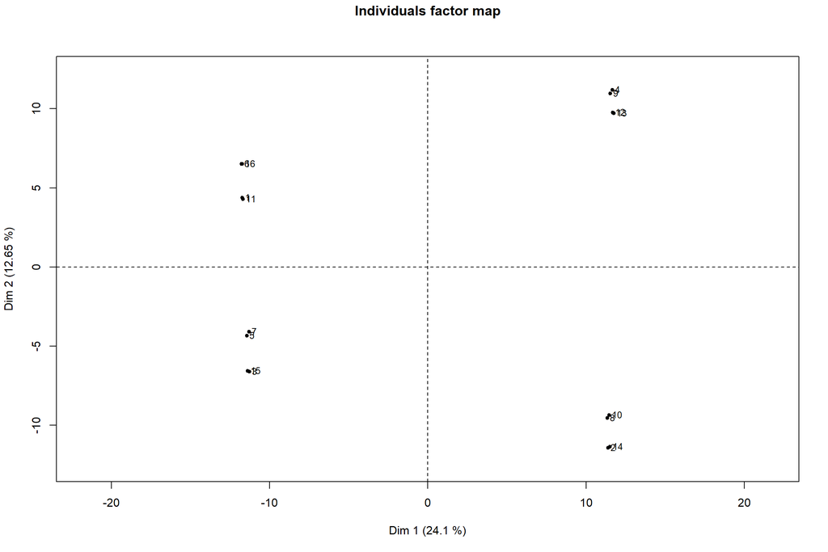

```r
plot.HMFA(res.AFMH, choix = "ind", invisible = "quali", label = "none")
```

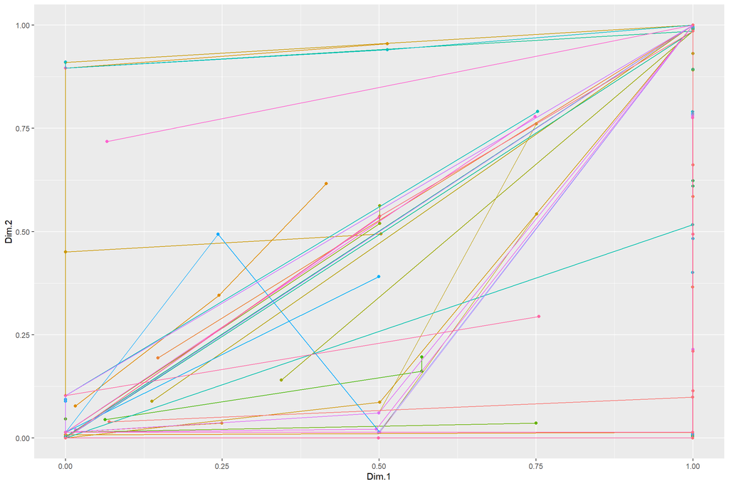

```r
library(plotly)

coord <- as.data.frame(coord)

coord$Enfant <- as.factor(rep(c(1:170), times = as.integer(res)))

fig1 <- coord %>% group_by(Enfant) %>%
  ggplot() +
  aes(x = Dim.1, y = Dim.2) +
  geom_point(aes(col = Enfant), alpha = 05.) + geom_line(aes(group = Enfant, col = Enfant)) +
  theme(legend.position = "none")

fig1
```

```r
ggplotly(fig1)
```

[interactive chart not shown]

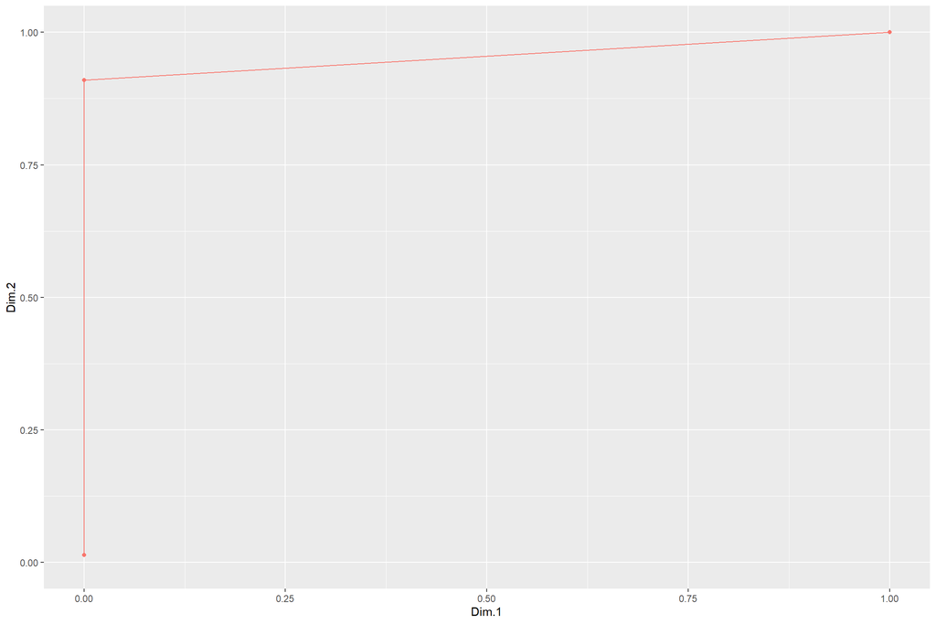

```r
coord %>% filter(Enfant == "24") %>%
  ggplot() +
  aes(x = Dim.1, y = Dim.2) +
  geom_point(aes(col = Enfant), alpha = 05.) + geom_line(aes(group = Enfant, col = Enfant)) +
  theme(legend.position = "none") +
  xlim(0,1) + ylim(0,1)
```

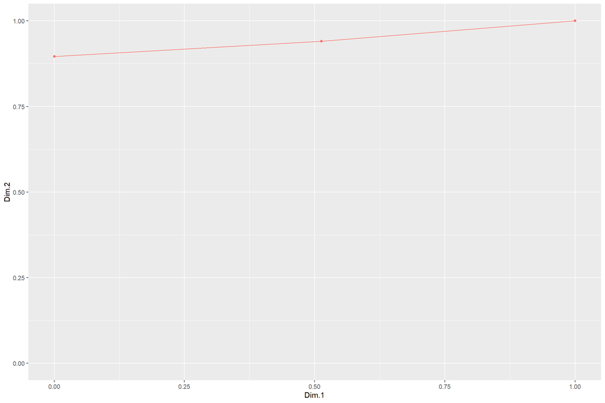

```r
coord %>% filter(Enfant == "86") %>%
  ggplot() +
  aes(x = Dim.1, y = Dim.2) +
  geom_point(aes(col = Enfant), alpha = 05.) + geom_line(aes(group = Enfant, col = Enfant)) +
  theme(legend.position = "none")+
  xlim(0,1) + ylim(0,1)
```

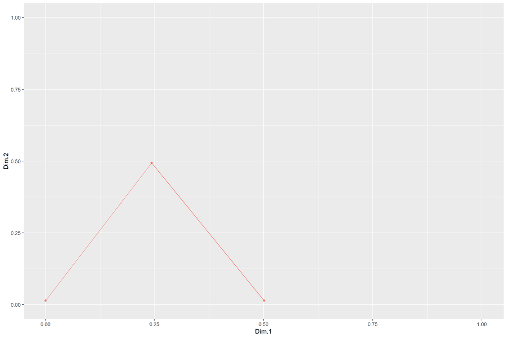

```r
coord %>% filter(Enfant == "108") %>%
  ggplot() +
  aes(x = Dim.1, y = Dim.2) +
  geom_point(aes(col = Enfant), alpha = 05.) + geom_line(aes(group = Enfant, col = Enfant)) +
  theme(legend.position = "none")+
  xlim(0,1) + ylim(0,1)
```

# 4 Seance 6 (TD en autonomie)

## 4.1 Introduction & protocole de type profil idéal

### 4.1.1 Introduction

Quelle politique alimentaire pour faire la transition ?

La question de l’évolution de nos systèmes agricoles et alimentaires est au cœur des débats autour de la transition agroécologique. La politique alimentaire est le domaine de la politique publique concernant la manière dont les aliments sont produits, transformés, distribués, achetés ou fournis. Les politiques alimentaires sont conçues pour influencer le fonctionnement du système alimentaire et agricole tout en garantissant les besoins en matière de santé humaine. Cela inclut souvent la prise de décisions concernant les techniques de production et de transformation, la commercialisation et la disponibilité dans l’intérêt d’atteindre ou de promouvoir des objectifs sociaux. La politique alimentaire peut être promulguée à n’importe quel niveau, du local au global, et par une agence gouvernementale ou une organisation. Notre analyse porte sur la nécessité de définir quelle politique alimentaire mettre en œuvre pour réussir la transition vers des systèmes plus durables. L’objectif est donc d’évaluer différents scénarios pour identifier les voies les plus souhaitables pour faire la transition.

### 4.1.2 Protocole

On souhaite construire des propositions de lois relatives aux transitions de la politique alimentaire afin de mettre en place des mesures permettant de tendre vers la gouvernance alimentaire de demain. On souhaite donc tester différentes propositions de lois, découlant de différents scénarios politiques. Pour réaliser la construction de l’espace des produits (stimuli), on veut capter le plus de variabilité afin que les contours de ce plan soient les plus larges possibles. Il faut donc définir les facteurs de variabilité et leurs niveaux (modalités). Les facteurs de variabilité retenus sont la production (mode de production des aliments, avec différents niveaux de productivité/impact sur l’environnement), l’accessibilité (régulation des prix par le marché ou interventionnisme de l’État) et la gouvernance (qui prend les décisions et à quel niveau).

Chaque facteur de variabilité est découpé en trois niveaux afin que les scénari reflètent au mieux l’ensemble du spectre des solutions politiques, le niveau intermédiaire permettant d’éviter une vision trop simpliste.

Pour ces 3 facteurs de variabilité, 3 niveaux (modalités) ont été retenus : Production : -1 (Productiviste), 0 (Mixte), +1 (Agroécologique) Accessibilité : -1 (Prix “vrai”), 0 (Régulé), +1 (Accès universel) Gouvernance : -1 (Global), 0 (Mixte), +1 (Local)

### 4.1.3 Plan d’experience :

On souhaite tester l’effet de ces 3 facteurs à 3 modalités. Si l’on réalise le plan complet, c’est-à-dire toutes les combinaisons possibles, il faudrait réaliser 27 stimuli. Cela représente un nombre trop important de stimuli à évaluer pour chaque citoyen. On peut utiliser un carré latin pour réduire le nombre d’expériences à 9 tout en garantissant que tous les niveaux de nos facteurs soient représentés et sans répétition. Ce plan est pertinent pour notre analyse car il permet de proposer un éventail de stimulus présentant toutes les combinaisons de politiques possibles.

Une fois toutes nos combinaisons de facteurs réalisées, il faut définir des politiques publiques correspondant à la combinaison. Le tableau suivant résume les politiques proposées aux consommateurs :

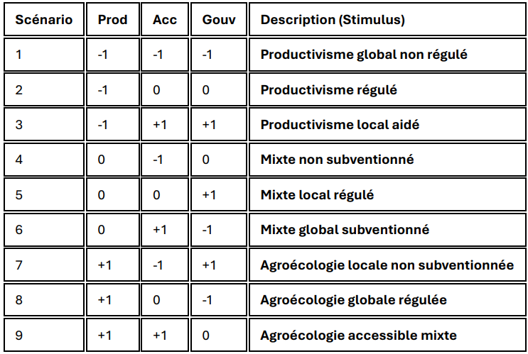

Dans la méthode du profil idéal adapté à un produit cosmétique et alimentaire, on demande au consommateur de décrire le produit sur plusieurs descripteurs. Pour les politiques publiques, il faut également réfléchir aux descripteurs. Il est plus compliqué de trouver des descripteurs englobant l’ensemble des aspects d’une politique publique.

On propose la liste d’attributs suivants pour évaluer nos scénarios de politiques publiques : - Équité sociale : à quel point cette politique permet de réduire les inégalités sociales. - Souveraineté alimentaire : à quel point cette politique permet de garantir la souveraineté alimentaire du territoire. - Interventionnisme de l’État : à quel point cette politique favorise l’intervention de l’État dans l’économie du pays. - Impact environnemental : à quel point cette politique participe à la réduction des impacts environnementaux du système alimentaire. - Protectionnisme : à quel point cette politique est protectionniste. - Décroissance : à quel point ce scénario favorise la décroissance. - Santé : à quel point cette politique prend en compte les besoins en matière de santé. - Education : à quel point cette politique favorise l’éducation des populations sur les sujets de l’alimentation.

Pour chacun de ces descripteurs, le consommateur devra indiquer sur une échelle de 0 à 10 à quel point la politique publique répond à ce critère. Puis il devra indiqué à quel point il aimerait que la politque réponde à ce critère (notion d’idéal).

Pour la mesure du liking, l’appréciation de la politique la question suivante est posée : dans l’ensemble, à quel point soutenez-vous ce scénario ?

L’objectif de la méthode de profil idéal est de chercher à maximiser le liking; représenté ici par le soutien ou l’adhésion à une politique.

## 4.2 Traitement de données avec le package mirt

Nous allons maintenant traiter les réponses à un questionnaire qui porte sur une alimentation durable. Les 536 participants ont répondu à 48 questions en se positionnant sur une échelle de Likert. ## Chargement des données

```r
library(here)
data <- read.csv(here("Markdown/dataset","data_536.csv"))
```

### 4.2.1 Re-mapping

```r
# Sélection des colonnes avec affirmations
items <- data %>%
  select(matches("Dans.quelle.mesure.êtes.vous.d.accord"))

# Recodage des réponses
mapping <- c(
  "Pas du tout d'accord" = 1,
  "Plutôt pas d'accord" = 2,
  "Ni d’accord ni pas d’accord (neutre)" = 3,
  "Plutôt d’accord" = 4,
  "Tout à fait d’accord" = 5
)

items_num <- as.data.frame(apply(items, 2, function(col) {
  unname(mapping[col])
}))
```

### 4.2.2 Elaboration d’un modèle

```r
mod1 <- mirt(items_num, 1, itemtype = "graded")
```

```r
#Évaluation de la qualité de l'ajustement
fit_stats <- M2(mod1, type = "C2")
print(fit_stats)
```

```
##             M2   df p    RMSEA   RMSEA_5  RMSEA_95      SRMSR       TLI
## stats 7504.233 1080 0 0.105444 0.1031014 0.1076031 0.08740079 0.8839526
##             CFI
## stats 0.8888908
```

On constate que le modèle initial, qui inclut l’ensemble des 48 affirmations, présente un mauvais ajustement aux données (RMSEA > 0.08 et CFI < 0.95). On rappelle que le RMSEA (Root Mean Square Error of Approximation) mesure la quantité de “bruit” ou d’erreur qui reste inexpliqué par le modèle. Nous avons déjà vu le seuil de 0.08 dans la littérature nous nous sommes donc permis de l’utiliser aussi, mais cela peut être critiqué. Le CFI (Comparative Fit Index) va comparer le modèle à un “modèle nul” (sans structure, sans variable latente). Le seuil de 0.95 est souvent utilisé dans la littérature. (voir par exemple https://mqr.teluq.ca/confirmer.html )

Il n’est pas surprenant que le modèle soit mal ajusté, compte tenu de la longueur du questionnaire. Avec autant d’items mesurant le même concept (l’engagement pour une alimentation durable), il y a inévitablement des redondances. Or, ces répétitions créent de la dépendance locale, ce qui contredit les hypothèses de base du modèle IRT.

Pour corriger cela et obtenir un modèle valide, nous allons procéder par élimination en suivant deux règles précises :

Supprimer les doublons : on repère les paires d’items qui ont une corrélation résiduelle trop forte (seuil fixé à 0.25), signe qu’ils posent quasiment la même question. On rappelle qu’ici la corrélation résiduelle mesure le “bruit” qui relie deux questions pour des mauvaises raisons (mots similaires, contextes similaires, formulation identique).

Supprimer les items “faibles” : on retire les affirmations qui ont un loading trop bas, car elles ne mesurent pas assez bien la variable latente.

Nous avons ainsi créé une fonction qui automatise cette sélection. Elle cherche itérativement le meilleur modèle en éliminant les items problématiques un par un, en justifiant chaque suppression (soit pour cause de redondance, soit pour manque de pertinence).

```r
optimize_mirt_model <- function(df,
                                target_RMSEA = 0.08,
                                target_CFI = 0.95,
                                min_items = 10, # On s'arrête s'il reste trop peu d'items
                                ld_cutoff = 0.25, # Seuil pour la dépendance locale
                                min_loading = 0.40) # Seuil pour les mauvais loadings
{
  current_items <- df
  iteration <- 0
  log_history <- list()

  repeat {
    iteration <- iteration + 1
    cat("\n------------------------------------------------\n")
    cat(paste("ITERATION", iteration, "- Nombre d'items restants :", ncol(current_items), "\n"))

    # Fit du modèle
    mod <- mirt(current_items, 1, itemtype = "graded", verbose = FALSE)

    # Récupération des statistiques (CFI ET RMSEA)
    try({
      fit_stats <- M2(mod, type = "C2")
      print(fit_stats)

      rmsea <- fit_stats$RMSEA
      cfi <- fit_stats$CFI

      # Condition de SUCCÈS
      if (!is.na(rmsea) && !is.na(cfi) && rmsea <= target_RMSEA && cfi >= target_CFI) {
        cat("\n>>> SUCCÈS : Le modèle a atteint les critères de qualité !\n")
        return(list(final_model = mod, final_items = colnames(current_items), history = log_history))
      }
    }, silent = TRUE)

    # Condition d'ARRÊT (trop peu d'items)
    if (ncol(current_items) <= min_items) {
      cat("\n>>> ARRÊT : Nombre minimum d'items atteint sans validation parfaite.\n")
      return(list(final_model = mod, final_items = colnames(current_items), history = log_history))
    }

    # DIAGNOSTIC : Quoi supprimer et pourquoi?

    # Check les Loadings
    params <- summary(mod, verbose = FALSE)
    loadings <- params$rotF
    bad_loading_idx <- which.min(loadings) # On prend le pire (le plus petit)
    worst_loading_val <- loadings[bad_loading_idx]

    item_to_remove <- NULL
    reason <- ""

    # Priorité 1 : On supprime d'abord les items avec des loadings vraiment nul (< 0.40),
    if (worst_loading_val < min_loading) {
      item_to_remove <- rownames(loadings)[bad_loading_idx]
      reason <- paste("Faible Loading (", round(worst_loading_val, 3), ")")
    } else {
      # Priorité 2 : Dépendance Locale
      residus <- residuals(mod, type = 'Q3', verbose = FALSE)
      res_matrix <- as.matrix(residus)
      res_matrix[upper.tri(res_matrix, diag = TRUE)] <- 0 # On ignore la diagonale et les doublons

      # Trouver la pire paire (avec la plus grosse corrélation résiduelle)
      max_ld <- max(abs(res_matrix))

      if (max_ld > ld_cutoff) {
        worst_pair <- which(abs(res_matrix) == max_ld, arr.ind = TRUE)[1, ]
        item1 <- rownames(res_matrix)[worst_pair[1]]
        item2 <- colnames(res_matrix)[worst_pair[2]]

        # Entre les deux items corrélés, on supprime celui qui a le loading le plus faible
        load1 <- loadings[item1, ]
        load2 <- loadings[item2, ]

        if (load1 < load2) {
          item_to_remove <- item1
        } else {
          item_to_remove <- item2
        }
        reason <- paste("Dépendance locale forte (r =", round(max_ld, 2), ") avec", if(item_to_remove == item1) item2 else item1)
      }
    }

    # Exécution de la suppression
    if (!is.null(item_to_remove)) {
      cat(paste(">>> SUPPRESSION :", item_to_remove, "\nRAISON :", reason, "\n"))
      current_items <- current_items %>% select(-all_of(item_to_remove))
      log_history[[iteration]] <- paste("Removed", item_to_remove, "because", reason)
    } else {
      cat("\n>>> FIN : Plus aucun critère d'exclusion flagrant trouvé, mais le fit n'est pas parfait.\n")

      return(list(final_model = mod, final_items = colnames(current_items), history = log_history))
    }
  }
}



resultat <- optimize_mirt_model(as.data.frame(items_num))

# Le modèle final est stocké dans resultat$final_model
final_mod <- resultat$final_model

save(final_mod, file ="final_mod.RData")
```

```r
load(here("Markdown/sections", "final_mod.RData"))
```

Notre modèle n’est pas parfaitement ajusté, mais on l’a optimisé au mieux du point de vue du CFI et du RMSEA. On aimerait explorer la piste d’un modèle en deux dimensions malheureusement nous n’avons pas la puissance de calcul nécessaire pour faire tourner une fonction similaire à ce qu’on a fait ci-dessus, mais adapté à 2 dimensions. Nous avons essayé, mais le calcul n’était pas fini au bout de deux heures. Cependant notre modèle à un CFI et un RMSEA qui s’approche des valeurs cibles.

Pour évaluer la précision de mesure du trait latent de notre modèle final, on peut aussi évaluer sa fiabilité marginale.

$$Fiabilité =
\frac{Variance{\quad}du{\quad}score}{Variance{\quad}du{\quad}score +
variance{\quad}de{\quad}l'erreur }$$

Le score étant le niveau d’adhésion de nos individus à une alimentation durable.

```r
reliability <- fscores(final_mod, returnER = TRUE)
reliability
```

```
##        F1
## 0.9381596
```

On a une fiabilité marginale supérieure à 0.9 donc notre modèle mesure le trait latent (l’engagement à une alimentation durable) avec une grande précision.

## 4.3 Exploration des données

Maintenant, que nous avons choisi un modèle, nous pouvons à présent le faire “parler” sur nos données. On va aborder deux points : - La qualité du questionnaire : quels sont ses points forts, ses points faibles? - La réalité du terrain : comment se positionnent les participants sur l’engagement à une alimentation durable ?

### 4.3.1 Evaluation de la qualité du questionnaire

Tout d’abord nous allons la courbe caractéristiques des catégories. Il nous permet de visualiser la probabilité de choisir une réponse selon le niveau d’engagement de la personne.

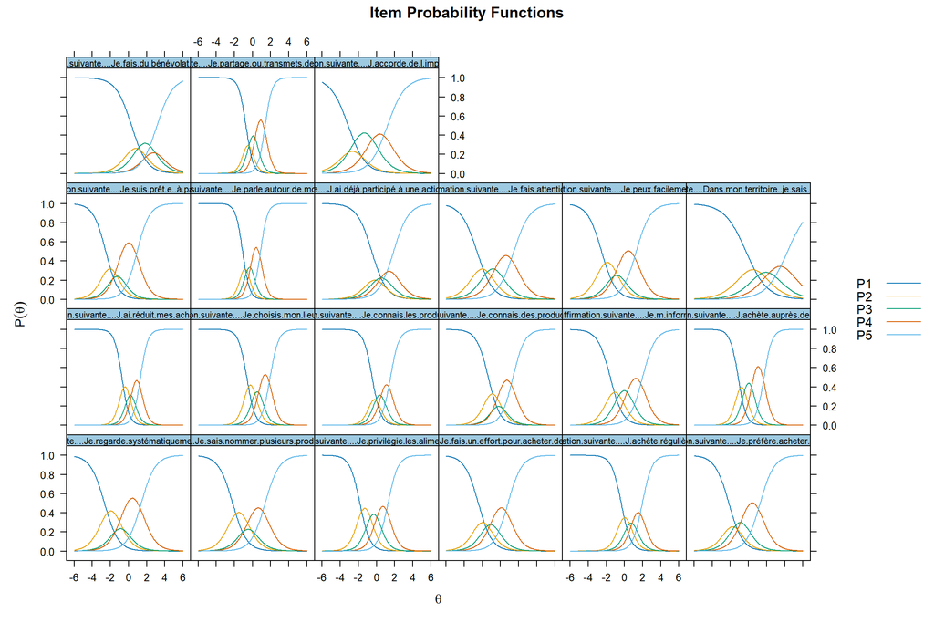

```r
plot(final_mod, type = "trace")
```

**L’axe des abscisse** $\theta$ représente le niveau de trait latent, ici “l’engagement envers une alimentation durable”. Les valeurs sont centrées autour de 0 allant de -6 (très faible engagement) à 6 (très fort engagement)

**L’axe des ordonnées** P($\theta$) représente la probabilité qu’un individu choisise une catégorie de réponse spécifique (Pas d’accord du tout, très d’accord)

**Les courbes P1 à P5** : Chaque courbe correspond à la probabilité conditionnelle de choisir l’une des 5 modalités de l’échelle de Likert

| Courbe | Modalité de réponse correspondant |
| --- | --- |
| P1 | Pas du tout d’accord |
| P2 | Plutot pas d’accord |
| P3 | Ni d’accord ni pas d’accord |
| P4 | Plutôt d’accord |
| P5 | Tout à fait d’accord |

**Interprétation générale des graphiques**

On voit donc qu’à faible niveau $\theta$, P1 est élevé. En effet les personnes peu engagées sur la variable latente “engagement envers l’alimentation durable”, vont avoir tendance à cocher plutt pas d’accord aux questions posé

A niveau moyen de $\theta$ P2 et P3 peuvent dominer

A haut niveau de $\theta$ P4 et surtout P5 montent. En effet^, les personnes très engagées ont tendance à cocher “Tout à fait d’accord”.

Les points où deux courbes se croisent à un seuil du modèle. C’est le niveau à partir duquel il est plus probable de passer d’une catégorie à une autre.

**Ce que ça nous dit sur le questionnaire**

Les pentes de nos graphiques sont nettes et descendent de manière verticale (surtout P1 et P5). Cela signifie que nos questions discriminent bien entre les individus peu engagés et très engagés. L’item est sensible aux variations de l’engagement. L’ordre des catégories est toujours respecté. On voit toujours de gauche à droite P1, P2, P3, P4, P5. Cela signifie que l’échelle de Likert est bien adapté dans notre questionnaire pour avoir un score très élevé (P5 par exemple) il faut avoir un niveau de trait latent $\theta$ plus élevé que pour avoir P4. On ne voit sur aucun graphique de courbe plate. Cela aurait indiqué que la modalité est inutile. En effet, des individus de tous les niveaux d’engagement auraient répondu la même réponse. Ce n’est pas le cas ici donc toutes les modalités sont utiles. En conclusion, ce graphique nous montre que le questionnaire est bien fait sur 3 aspects : - Les questions sont assez pertinentes pour différencier les individus en fonction de leur engagement. - L’échelle de Likert est bien adapté. - Le nombre de modalités est bon (pas de modalité inutile).

Ensuite, nous allons tracer un graphique d’information par items. L’idée ici est de trouver les questions qui se sont avéré les plus utiles pour calculer le score.

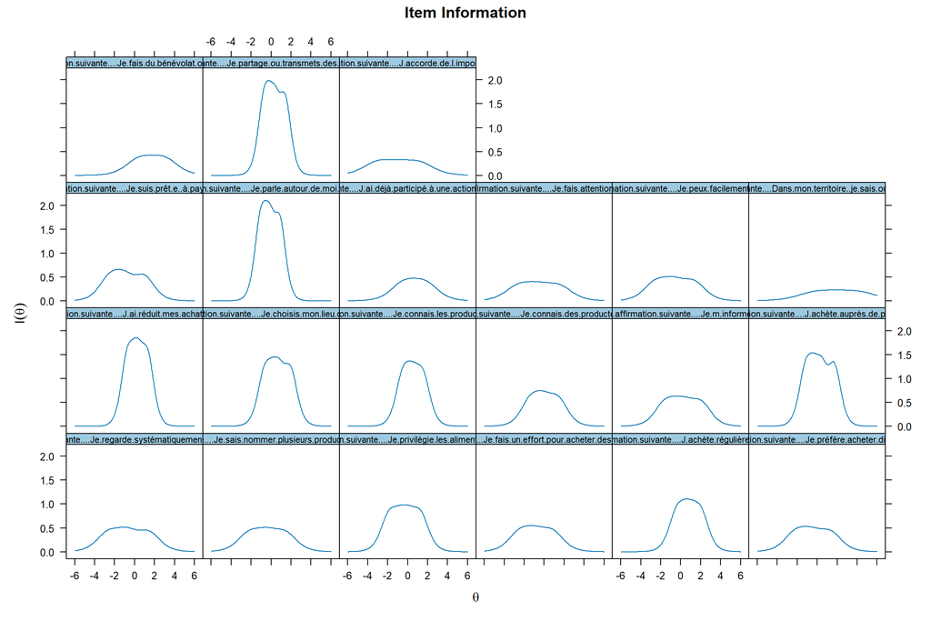

```r
plot(final_mod,type = "infotrace")
```

**L’axe des abscisse** représente le niveau de trait latent $\theta$ **L’axe des ordonnées** I($\theta$) représente la fonction d’information de Fisher. C’est l’inverse de la variance de l’erreur d’estimation. Plus I($\theta$) est élevé, plus l’erreur de mesure est faible.

**Interprétation générale** Plus un pic est élevé plus la question est performante (elle tranche net entre les individus très engagés et faiblement engagés). La position du pic nous permet de savoir entre qui il différencie. Si le pic est centré sur 0, la question discrimine les gens “moyens”. Si le pic est plutôt à gauche l’item, est informatif uniquement sur les gens peu engagées. Enfin si la courbe forme un plateau l’item est peu précis.

- “Je.partage.ou.transmets.des.informations.concernant.des.producteurs.ou.initiatives.locales..”
- “Je.parle.autour.de.moi.des.producteurs.ou.produits.locaux.que.je.recommande..”

-“J.ai.réduit.mes.achats.en.grande.surface.pour.favoriser.des.circuits.courts..”

Donc ces questions nous sont très utiles pour différencier les individus faiblement engagés et très engagés.

On voit des plateaux à droite pour les questions :

- “Dans.mon.territoire..je.sais.où.trouver.des.aides.pour.accéder.à.une.alimentation.de.qualité..”
- “Je.fais.du.bénévolat.ou.j.apporte.un.soutien.à.une.structure.alimentaire.locale..”

Ces questions sont informatives pour les personnes très engagées, mais de manière peu précise.

Enfin, nous allons étudier la zone de confiance du questionnaire. Pour cela, nous allons superposer la quantité d’information (bleu) et la marge d’erreur (rouge).

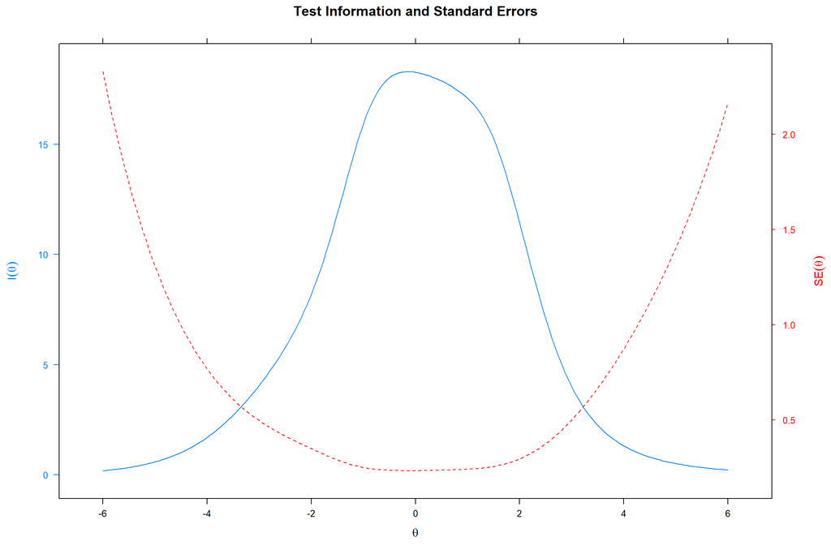

```r
plot(final_mod, type = "infoSE")
```

Nous voyons ainsi, que le questionnaire est très fiable pour les individus moyennement engagés (theta entre -2 et 2). En revanche, pour les individus extrêmes(à 6 ou -6) on a plus d’erreurs, il faut donc prendre avec des pincettes les scores calculés pour les individus avec un score latent extrêmes.

### 4.3.2 La réalité du terrain

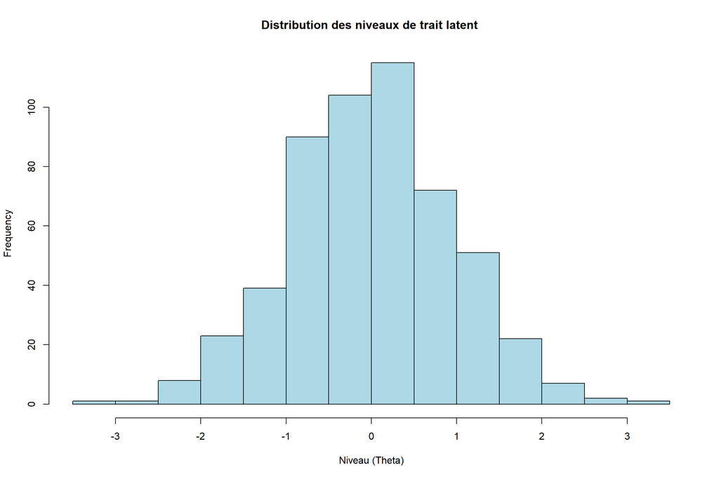

```r
scores <- fscores(final_mod)
hist(scores, main = "Distribution des niveaux de trait latent ", xlab = "Niveau (Theta)", col="lightblue", breaks=20)
```

On voit donc que la distribution des répondants suit une loi normale. Ainsi, il y a peu d’individus très faiblement engagé ou très engagé et beaucoup d’individus moyens. Ce qui est plutôt attendu.

Nous allons maintenant voir une carte qui nous montre le score latent moyen de chaque région ainsi que son nombre de participation.

```r
df_scores_region <- data.frame(
  Region = data$Dans.quelle.région.habitez.vous..,
  Score = scores[,1]
)

# Dataframe pour la carte
df_map_data <- df_scores_region %>%
  group_by(Region) %>%
  summarise(
    Score_Moyen = mean(Score, na.rm = TRUE),
    Nb_Repondants = n() # Utile pour voir si une moyenne est fiable
  )

# Donnée pour le fond de carte
url_geojson <- "https://raw.githubusercontent.com/gregoiredavid/france-geojson/master/regions.geojson"
france_regions <- st_read(url_geojson, quiet = TRUE)

df_map_data <- df_map_data %>%
  mutate(Region_Join = Region)

map_final <- france_regions %>%
  left_join(df_map_data, by = c("nom" = "Region_Join"))


# Palette
bins <- c(-1, -0.5, -0.2, 0, 0.2, 0.5, 1)
pal <- colorBin("RdBu", domain = map_final$Score_Moyen, bins = bins, reverse = FALSE)

#Le graphique Leaflet
leaflet(data = map_final) %>%
  addProviderTiles(providers$CartoDB.Positron) %>% # Fond de carte épuré
  addPolygons(
    fillColor = ~pal(Score_Moyen),
    weight = 2,
    opacity = 1,
    color = "white",
    dashArray = "3",
    fillOpacity = 0.7,
    highlight = highlightOptions(
      weight = 5,
      color = "#666",
      dashArray = "",
      fillOpacity = 0.7,
      bringToFront = TRUE),
    label = ~paste0(nom, " : ", round(Score_Moyen, 2), " (N=", Nb_Repondants, ")"),
    labelOptions = labelOptions(
      style = list("font-weight" = "normal", padding = "3px 8px"),
      textsize = "15px",
      direction = "auto")) %>%
  addLegend(pal = pal, values = ~Score_Moyen, opacity = 0.7, title = "Score d'Engagement Moyen",
            position = "bottomright")
```

[interactive chart not shown]

On voit que la Nouvelle-Aquitaine a le score moyen le plus élevé avec 0.52. Cependant, c’est un résultat critiquable car seulement 30 répondant viennent de Nouvelle-Aquitaine. La région avec le plus de répondant est la Bretagne avec 181 individus, ce qui représente environ un tiers des participants du questionnaire. Elle a un score moyen de -0.03.

Maintenant, nous allons voir la distribution du score latent pour chaque région.

[figure not shown]

```r
# On enlève les NA et on trie les régions par niveau d'engagement médian

plot_data <- df_scores_region %>%
  filter(!is.na(Region)) %>%
  add_count(Region, name = "count") %>%
  mutate(Region_Label = paste0(Region, " (n=", count, ")")) %>%
  mutate(Region = forcats::fct_reorder(Region, Score, .fun = median))

# GRAPHIQUE
ggplot(plot_data, aes(x = Score, y = Region_Label, fill = stat(x))) +
  geom_density_ridges(
    fill = "lightblue",
    color = "grey30",
    scale = 1.5,        # Pas de bosse trop haute
    rel_min_height = 0.01, # Coupe les queue trop plate
    alpha = 0.8         # Transparence (pour voir les chevauchements)
  )+
  theme_minimal() +
  labs(title = "Distribution des scores latents par région (triées par médiane)",
       x = "Niveau d'Engagement (Theta)",
       y = "") +
  theme(
    plot.title = element_text(face = "bold", size = 14),
    axis.text.y = element_text(size = 11, face = "bold"), # Gros texte pour les régions
  )
```